# Baseball data

Peter Ralph

Advanced Biological Statistics

# Baseball

## Baseball

We have a dataset of batting averages of baseball players, having

1. name
2. position
3. number of at bats
4. number of hits
5. height
6. weight
7. handedness

```r
batting <- read.csv("data/BattingAveragePlus.csv", header=TRUE, stringsAsFactors=TRUE)
head(batting)
```

```
##             Player     PriPos Hits AtBats PlayerNumber PriPosNumber  playerID weight height bats birthYear      debut  finalGame
## 1 Aaron Cunningham Left Field   17     97          198            7 cunniaa01    215     71    R      1986 2008-08-31 2012-07-24
## 2     Aaron Harang    Pitcher    4     56          360            1 haranaa01    260     79    R      1978 2002-05-25 2015-10-03
## 3       Aaron Hill   2nd Base  184    609          394            4  hillaa01    200     71    R      1982 2005-05-20 2016-10-01
## 4     Aaron Laffey    Pitcher    0      1          482            1 laffeaa01    190     71    L      1985 2007-08-04 2015-07-31
## 5       Aaron Loup    Pitcher    0      1          522            1  loupaa01    210     71    L      1987 2012-07-14 2016-09-30
## 6        Adam Dunn   1st Base  110    539          242            3  dunnad01    285     78    L      1979 2001-07-20 2014-09-28
```

The *overall* batting average of the 886 players is 0.254768.

Here is the average by position.

```r
batting %>% group_by(PriPos) %>%
    summarise(num=n(), BatAvg=sum(Hits)/sum(AtBats)) %>%
    select(PriPos, num, BatAvg)
```

```
## # A tibble: 9 × 3
##   PriPos         num BatAvg
##   <fct>        <int>  <dbl>
## 1 1st Base        77  0.260
## 2 2nd Base        69  0.256
## 3 3rd Base        73  0.265
## 4 Catcher         95  0.247
## 5 Center Field    61  0.265
## 6 Left Field      96  0.258
## 7 Pitcher        305  0.130
## 8 Right Field     53  0.263
## 9 Shortstop       57  0.255
```

## Questions?

1. What’s the overall batting average?
2. Do some positions tend to be better batters?
3. How much variation in batting average is there between players of the same position?
4. Do height or weight predict batting average?

**Exercise:**

*Come up with some quick-and-dirty statistics to answer these questions.*

# Predicting probabilities

*Motivation:*

```r
lm( Hits/AtBats ~ PriPos + weight + height, data=batting )
```

which is
$$\begin{aligned}
\frac{\text{Hits}_i}{\text{AtBats}_i} &\sim \Normal(\mu_i,
\sigma) \\
\mu_i &= \beta_0 + \beta_{\text{PriPos}_i} + \beta_w w_i +
\beta_h h_i
\end{aligned}$$

*But:* that’s not right - `Hits/AtBats` is between 0 and 1!

And, 2/5 is very different than 2000/5000!

## A better Binomial model

$$\begin{aligned}
\text{Hits}_i &\sim \Binom(\text{AtBats}_i, \mu_i) \\
\mu_i &= \beta_0 + \beta_{\text{PriPos}_i} + \beta_w w_i +
\beta_h h_i
\end{aligned}$$

*But:* what’s to keep $\mu_i$ between 0 and 1?

# The logistic function

## The logistic function

$$\begin{aligned}
\logistic(x) = \frac{1}{1 + e^{-x}} .
\end{aligned}$$

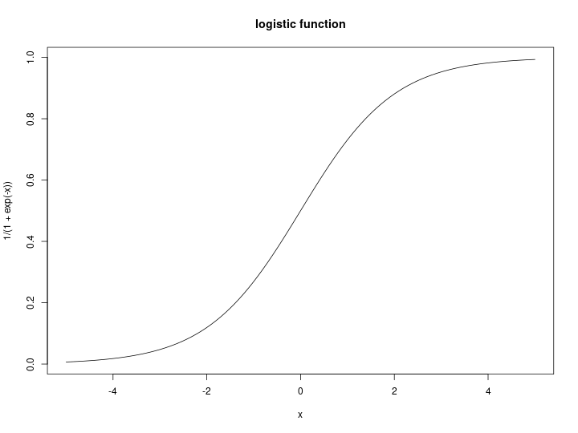

## … is the inverse of the logit function

$$\begin{aligned}
\logit(x) = \log\left(\frac{x}{1-x}\right) .
\end{aligned}$$

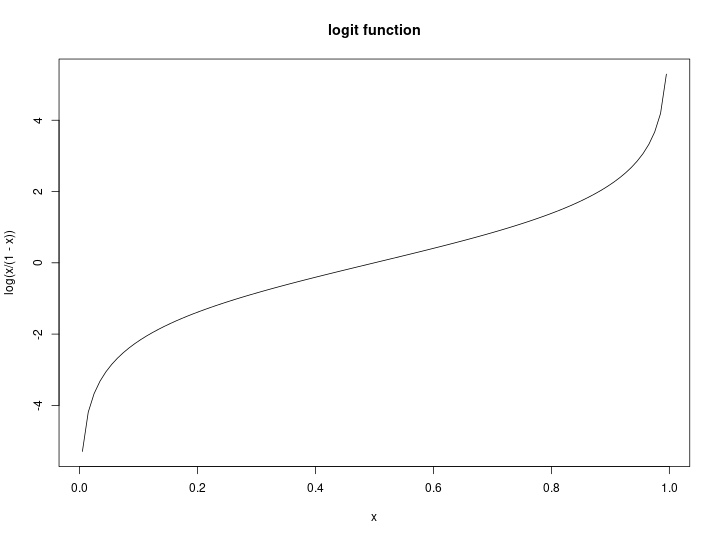

# Let’s build a model

## Binomial response with logistic predictor

$$\begin{aligned}
Z_i &\sim \Binom(N_i, \theta_i) \\
\theta_i &= \logistic(\mu_i)
\end{aligned}$$

For the $i$th player:

- $N_i$: number of *at-bats*
- $Z_i$: number of *hits*
- $\theta_i$: “true” batting average

## Everyone is the same

$$\begin{aligned}
Z_i &\sim \Binom(N_i, \theta_i) \\
\theta_i &= \logistic(\mu_i) \\
\mu_i &= \beta_0
\end{aligned}$$

For the $i$th player:

- $N_i$: number of *at-bats*
- $Z_i$: number of *hits*
- $\theta_i$: “true” batting average

and

- $\beta_0$: overall mean logit batting avg

## All pitchers are the same

$$\begin{aligned}
Z_i &\sim \Binom(N_i, \theta_i) \\
\theta_i &= \logistic(\mu_i) \\
\mu_i &= \beta_{p_i}
\end{aligned}$$

For the $i$th player:

- $N_i$: number of *at-bats*
- $Z_i$: number of *hits*
- $p_i$: *position*

and

- $\beta_p$: mean logit batting avg of position $p$

# First model, with brms

## First, we need priors!

$$\begin{aligned}
Z_i &\sim \Binom(N_i, \theta_i) \\
\theta_i &= \logistic(\mu_i) \\
\mu_i &= \beta_{p_i}
\end{aligned}$$
and
$$\begin{aligned}
\beta_p &\sim \Normal(0, 5)
\end{aligned}$$

For the $i$th player:

- $N_i$: number of *at-bats*
- $Z_i$: number of *hits*
- $p_i$: *position*

and

- $\beta_p$: mean logit batting avg of position $p$

## Fit the model

We’ll see more about [brms](https://paul-buerkner.github.io/brms/reference/brm.html) soon!

```r
fm <- brm(
      Hits  | trials(AtBats) ~ 0 + PriPos,
      data=batting,
      family='binomial',
      prior = c(prior(normal(0, 5), class = b)),
      iter = 2000, chains = 3
)
```

## Check convergence

```r
print(fm)
```

```
##  Family: binomial
##   Links: mu = logit
## Formula: Hits | trials(AtBats) ~ 0 + PriPos
##    Data: batting (Number of observations: 886)
##   Draws: 3 chains, each with iter = 2000; warmup = 1000; thin = 1;
##          total post-warmup draws = 3000
##
## Population-Level Effects:
##                   Estimate Est.Error l-95% CI u-95% CI Rhat Bulk_ESS Tail_ESS
## PriPos1stBase        -1.05      0.02    -1.08    -1.02 1.00     4554     2544
## PriPos2ndBase        -1.07      0.02    -1.10    -1.04 1.00     4371     2428
## PriPos3rdBase        -1.02      0.02    -1.05    -0.99 1.00     4270     2285
## PriPosCatcher        -1.12      0.02    -1.15    -1.08 1.00     4080     2153
## PriPosCenterField    -1.02      0.02    -1.05    -0.99 1.00     4799     1857
## PriPosLeftField      -1.06      0.02    -1.09    -1.02 1.00     4726     2545
## PriPosPitcher        -1.90      0.04    -1.99    -1.82 1.00     4558     2304
## PriPosRightField     -1.03      0.02    -1.06    -1.00 1.00     4315     2241
## PriPosShortstop      -1.07      0.02    -1.11    -1.03 1.00     3849     2180
##
## Draws were sampled using sampling(NUTS). For each parameter, Bulk_ESS
## and Tail_ESS are effective sample size measures, and Rhat is the potential
## scale reduction factor on split chains (at convergence, Rhat = 1).
```

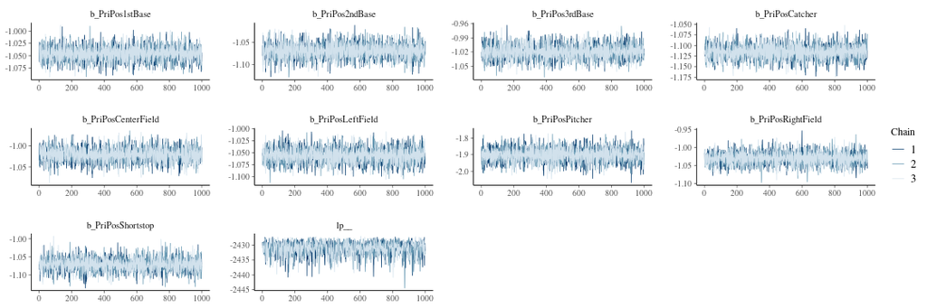

```r
mcmc_trace(fm)
```

## Results: on a logit scale

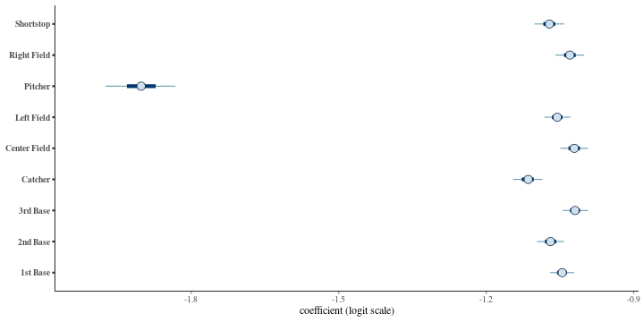

```r
mcmc_intervals(fm, regex_pars="b_PriPos.*") +
    scale_y_discrete(labels=levels(batting$PriPos)) +
    xlab("coefficient (logit scale)")
```

## Results: with `predict( )`

```r
pos_df <- data.frame(
            PriPos=levels(batting$PriPos),
            AtBats=10000)
fm_post <- predict(fm, newdata=pos_df)
cbind(pos_df, fm_post)
```

```
##         PriPos AtBats Estimate Est.Error     Q2.5    Q97.5
## 1     1st Base  10000 2599.869  52.70881 2495.000 2707.000
## 2     2nd Base  10000 2554.882  53.91151 2450.000 2663.000
## 3     3rd Base  10000 2651.301  54.53799 2545.000 2755.025
## 4      Catcher  10000 2470.508  53.82029 2366.000 2577.000
## 5 Center Field  10000 2648.643  55.46119 2539.000 2758.025
## 6   Left Field  10000 2583.180  52.42603 2483.000 2685.000
## 7      Pitcher  10000 1300.044  59.46869 1187.000 1416.000
## 8  Right Field  10000 2631.686  55.95883 2519.975 2740.000
## 9    Shortstop  10000 2550.090  57.14899 2441.000 2664.025
```

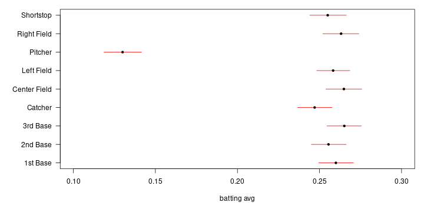

```r
par(mar=c(5,7,1,1)+.1)
plot(fm_post[,"Estimate"] / pos_df$AtBats, 1:nrow(pos_df), xlim=c(0.1, 0.3), xlab='batting avg', ylab='', yaxt='n', type='n')
segments(x0=fm_post[,"Q2.5"]/pos_df$AtBats, x1=fm_post[,"Q97.5"]/pos_df$AtBats, y0=1:nrow(pos_df), col='red')
points(fm_post[,"Estimate"] / pos_df$AtBats, 1:nrow(pos_df), pch=20)
axis(2, at=1:nrow(pos_df), labels=pos_df$PriPos, las=2)
```

## Are right fielders better than catchers?

Let’s get the posterior distribution of the difference between the two batting averages.

```r
fm_samps <- posterior_predict(fm, newdata=pos_df)
right_fielders <- fm_samps[,match("Right Field", pos_df$PriPos)]
catchers <- fm_samps[,match("Catcher", pos_df$PriPos)]
post_diff <- right_fielders - catchers
```

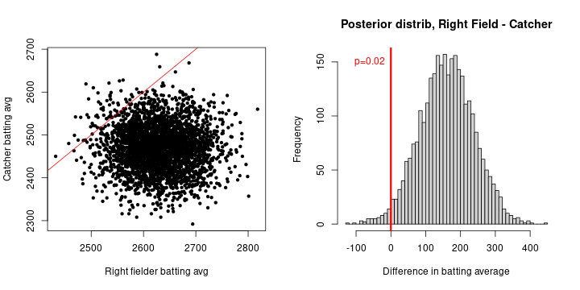

## Goodness-of-fit

*Is* this a good model for the data?

```r
fm_pp <- predict(fm)
head(fm_pp)
```

```
##         Estimate  Est.Error Q2.5 Q97.5
## [1,]  24.9460000  4.2487372   17    33
## [2,]   7.2473333  2.5296164    3    13
## [3,] 155.8523333 10.8682673  135   177
## [4,]   0.1276667  0.3337739    0     1
## [5,]   0.1206667  0.3257938    0     1
## [6,] 140.0776667 10.3903619  120   161
```

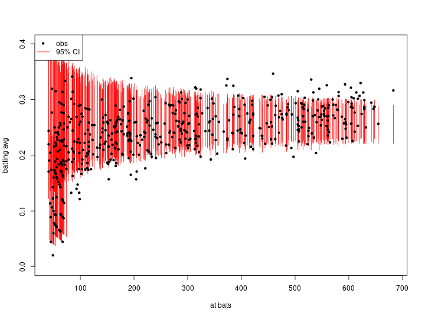

# Exercise

## In groups

Simulate from the model:

1. Make up 20 players’ names, positions, and at-bats,
2. simulate their true batting averages as on the right,
3. and draw their Hits using `rbinom( )`.

Then, fit the model! (time remaining)

$$\begin{aligned}
Z_i &\sim \Binom(N_i, \theta_i) \\
\theta_i &= \frac{1}{1 + \exp(-\mu_i)} \\
\mu_i &= \beta_{p_i} + \epsilon_i \\
\epsilon_i &\sim \Normal(0, 0.05) .
\end{aligned}$$

with:

- $\beta_\text{pitcher} = 0.15$
- and all other $\beta_p = 0.24$

## IN CLASS

```r
df <- data.frame(
    name=sample(LETTERS, 20),
    PriPos=sample(unique(batting$PriPos), 20, replace=TRUE),
    AtBats=rpois(20, 30)
)
beta <- rep(0.24, 9)
names(beta) <- unique(batting$PriPos)
beta['Pitcher'] <- 0.15
df$mu <- beta[as.character(df$PriPos)] + rnorm(20, sd=0.05)
df$theta <- 1/(1 + exp(-df$mu))
df$Z <- rbinom(nrow(df), size=df$AtBats, prob=df$theta)
```

# Back to the model

## Everyone is different, but pitchers are similar

$$\begin{aligned}
Z_i &\sim \Binom(N_i, \theta_i) \\
\theta_i &= \logistic(\mu_i) \\
\mu_i &= \beta_{p_i} + \epsilon_i \\
\epsilon_i &\sim \Normal(0, \sigma)
\end{aligned}$$

For the $i$th player:

- $N_i$: number of *at-bats*
- $Z_i$: number of *hits*
- $p_i$: *position*
- $\epsilon_i$: difference to typical for position

and

- $\beta_p$: batting avg for position $p$
- $\sigma$: size of differences between players

## Add in height and weight

$$\begin{aligned}
Z_i &\sim \Binom(N_i, \theta_i) \\
\theta_i &= \logistic(\mu_i) \\
\mu_i &= \beta_{p_i} + \beta_h h_i + \beta_w w_i + \epsilon_i \\
\epsilon_i &\sim \Normal(0, \sigma)
\end{aligned}$$

For the $i$th player:

- $N_i$: number of *at-bats*
- $Z_i$: number of *hits*
- $p_i$: *position*
- $\epsilon_i$: difference to typical for position
- $h_i$, $w_i$: height and weight

and

- $\beta_p$: batting avg for position $p$
- $\sigma$: size of differences between players
- $\beta_h$, $\beta_w$: coefficients on height and weight

## Fit the model

Scaling variables can improve convergence:

```r
library(brms)
batting$scaled_height <- (batting$height - mean(batting$height))/sd(batting$height)
batting$scaled_weight <- (batting$weight - mean(batting$weight))/sd(batting$weight)
logistic_fit <- brm(
      Hits  | trials(AtBats) ~ 0 + scaled_weight + scaled_height + PriPos + (1 | PriPos:Player),
      data = batting,
      family = "binomial",
      prior = c(prior(normal(0, 5), class = b),
                prior(normal(0, 5), class = sd)),
      iter = 2000, chains = 3
)
```

## Check convergence

```r
print(logistic_fit)
```

```
##  Family: binomial
##   Links: mu = logit
## Formula: Hits | trials(AtBats) ~ 0 + scaled_weight + scaled_height + PriPos + (1 | PriPos:Player)
##    Data: batting (Number of observations: 886)
##   Draws: 3 chains, each with iter = 2000; warmup = 1000; thin = 1;
##          total post-warmup draws = 3000
##
## Group-Level Effects:
## ~PriPos:Player (Number of levels: 886)
##               Estimate Est.Error l-95% CI u-95% CI Rhat Bulk_ESS Tail_ESS
## sd(Intercept)     0.14      0.01     0.12     0.16 1.00     1100     1712
##
## Population-Level Effects:
##                   Estimate Est.Error l-95% CI u-95% CI Rhat Bulk_ESS Tail_ESS
## scaled_weight         0.02      0.01    -0.01     0.04 1.00     1391     1765
## scaled_height        -0.01      0.01    -0.03     0.02 1.00     1515     1700
## PriPos1stBase        -1.08      0.03    -1.14    -1.03 1.00     1675     1999
## PriPos2ndBase        -1.09      0.03    -1.15    -1.04 1.00     1391     2012
## PriPos3rdBase        -1.06      0.02    -1.11    -1.01 1.00     1686     2098
## PriPosCatcher        -1.16      0.03    -1.21    -1.11 1.00     1510     1792
## PriPosCenterField    -1.05      0.03    -1.10    -0.99 1.00     1604     1971
## PriPosLeftField      -1.10      0.02    -1.14    -1.05 1.00     1672     1816
## PriPosPitcher        -1.92      0.05    -2.01    -1.83 1.00     4370     2223
## PriPosRightField     -1.05      0.03    -1.11    -1.00 1.00     1487     1623
## PriPosShortstop      -1.10      0.03    -1.16    -1.04 1.00     1593     1880
##
## Draws were sampled using sampling(NUTS). For each parameter, Bulk_ESS
## and Tail_ESS are effective sample size measures, and Rhat is the potential
## scale reduction factor on split chains (at convergence, Rhat = 1).
```

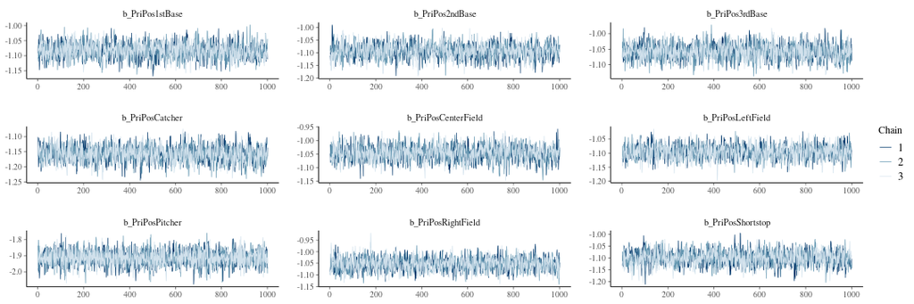

```r
mcmc_trace(logistic_fit, regex_pars="b_PriPos.*")
```

## Look at results

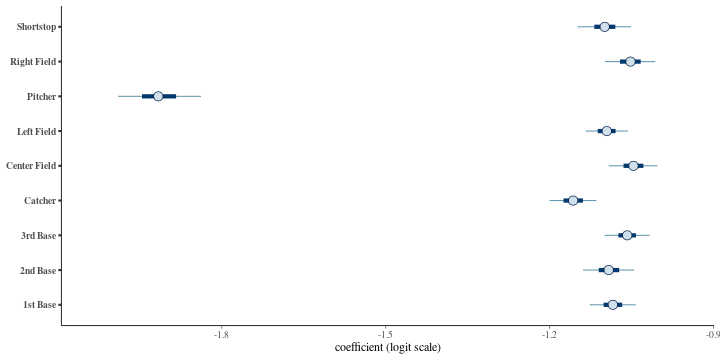

```r
samps <- as_draws_array(logistic_fit)
mcmc_intervals(samps, regex_pars=c("b_PriPos.*")) +
    scale_y_discrete(labels=levels(batting$PriPos)) +
    xlab("coefficient (logit scale)")
```

## In the natural scale

```r
conditional_effects(logistic_fit, effects="PriPos")
```

```
## Setting all 'trials' variables to 1 by default if not specified otherwise.
```

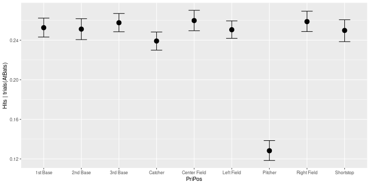

## Let’s look at some players?

`posterior_epred()` gives posterior samples of expected responses:

```r
players <- c("Mark Buehrle", "Matt Harvey", "Mike Leake")
(player_data <- subset(batting, Player %in% players))
```

```
##           Player  PriPos Hits AtBats PlayerNumber PriPosNumber  playerID weight height bats birthYear      debut  finalGame scaled_height scaled_weight
## 592 Mark Buehrle Pitcher    3     67          102            1 buehrma01    240     74    L      1979 2000-07-16 2015-10-04     0.2568063     1.3951531
## 617  Matt Harvey Pitcher    6     18          369            1 harvema01    215     76    R      1989 2012-07-26 2016-07-04     1.1219410     0.1723515
## 651   Mike Leake Pitcher   18     61          494            1 leakemi01    170     70    R      1987 2010-04-11 2016-09-28    -1.4734630    -2.0286912
```

```r
player_preds <- posterior_epred(logistic_fit, newdata=player_data)
colnames(player_preds) <- players
player_preds <- player_preds / player_data$AtBats[col(player_preds)]
head(player_preds)
```

```
##      Mark Buehrle Matt Harvey Mike Leake
## [1,]   0.09942549   0.1245864  0.1421047
## [2,]   0.11107516   0.1217278  0.1673386
## [3,]   0.10992811   0.1252273  0.1388137
## [4,]   0.11775287   0.1740435  0.1717359
## [5,]   0.11167978   0.1089932  0.1302543
## [6,]   0.12496966   0.1673440  0.1560620
```

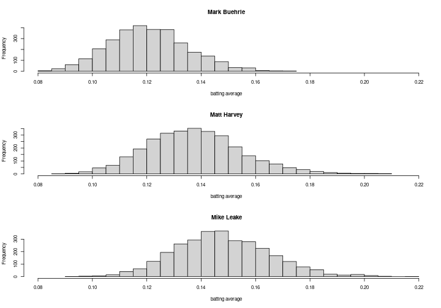

```r
layout(seq_along(players))
for (j in seq_along(players)) {
    hist(player_preds[,j], xlim=range(player_preds), main=players[j], xlab='batting average', breaks=30)
}
```

## Exercise:

What are some questions would you like to answer using this model?